# Assignment_7.1_HillZach

Zach Hill

April 28, 2019

#### a. Explain why you choose to remove data points from your âcleanâ dataset.

In last week’s assignment we opted not to remove the outliers as they contained all appropriate data and we felt the outliers were important to include. Arguably this approach could be faulty as it is possible some large chunk of land was sold with a tiny trailer on it, or a very small peice of land in an extremely expensive area was sold at a very high price. With the box plots showing numerous outliers like this though, leaving them in seemed to be a better idea.

#### b. Create two variables; one that will contain the variables Sale Price and Square Foot of Lot (same variables used from previous assignment on simple regression) and one that will contain Sale Price, Bedrooms, and Bath Full Count as predictors.

```r
sale_sfl <- lm(sale_price ~ sq_ft_lot, data = housing)
sale_bb <- lm(sale_price ~ sq_ft_lot + bedrooms + bath_full_count, data = housing)
```

#### c. Execute a summary() function on two variables defined in the previous step to compare the model results. What are the R2 and Adjusted R2 statistics? Explain what these results tell you about the overall model. Did the inclusion of the additional predictors help explain any large variations found in Sale Price?

```r
summary(sale_sfl)
```

```
##
## Call:
## lm(formula = sale_price ~ sq_ft_lot, data = housing)
##
## Residuals:
##      Min       1Q   Median       3Q      Max
## -2016064  -194842   -63293    91565  3735109
##
## Coefficients:
##              Estimate Std. Error t value Pr(>|t|)
## (Intercept) 6.418e+05  3.800e+03  168.90   <2e-16 ***
## sq_ft_lot   8.510e-01  6.217e-02   13.69   <2e-16 ***
## ---
## Signif. codes:  0 '***' 0.001 '**' 0.01 '*' 0.05 '.' 0.1 ' ' 1
##
## Residual standard error: 401500 on 12863 degrees of freedom
## Multiple R-squared:  0.01435,    Adjusted R-squared:  0.01428
## F-statistic: 187.3 on 1 and 12863 DF,  p-value: < 2.2e-16
```

```r
summary(sale_bb)
```

```
##
## Call:
## lm(formula = sale_price ~ sq_ft_lot + bedrooms + bath_full_count,
##     data = housing)
##
## Residuals:
##      Min       1Q   Median       3Q      Max
## -3566287  -153218   -51375    69545  3736381
##
## Coefficients:
##                  Estimate Std. Error t value Pr(>|t|)
## (Intercept)     1.429e+05  1.481e+04   9.649   <2e-16 ***
## sq_ft_lot       7.227e-01  5.910e-02  12.229   <2e-16 ***
## bedrooms        6.887e+04  4.027e+03  17.099   <2e-16 ***
## bath_full_count 1.458e+05  5.422e+03  26.888   <2e-16 ***
## ---
## Signif. codes:  0 '***' 0.001 '**' 0.01 '*' 0.05 '.' 0.1 ' ' 1
##
## Residual standard error: 381000 on 12861 degrees of freedom
## Multiple R-squared:  0.1127, Adjusted R-squared:  0.1125
## F-statistic: 544.3 on 3 and 12861 DF,  p-value: < 2.2e-16
```

For the first model, R^2 and Adjusted R^2 are 0.0144 and 0.0143 respectively. Since both values are so low, it shows there is little correlation between the lot square footage and the sale price. Additionally since both values are very close to one another, we can assume the model is generalized well.

#### d. Considering the parameters of the multiple regression model you have created. What are the standardized betas for each parameter and what do the values indicate?

```r
lm.beta(sale_sfl)
```

```
## sq_ft_lot
## 0.1198122
```

```r
lm.beta(sale_bb)
```

```
##       sq_ft_lot        bedrooms bath_full_count
##       0.1017484       0.1492025       0.2346207
```

This measurement is based on standard deviations, leaving measurement units out of the equation which should provide a better means of analysis for each predictor since they are comparable. In our case it shows the most significant predictor to be the number of full baths.

#### e. Calculate the confidence intervals for the parameters in your model and explain what the results indicate.

```r
confint(sale_sfl)
```

```
##                    2.5 %       97.5 %
## (Intercept) 6.343730e+05 6.492698e+05
## sq_ft_lot   7.291208e-01 9.728641e-01
```

```r
confint(sale_bb)
```

```
##                        2.5 %       97.5 %
## (Intercept)     113893.30200 1.719645e+05
## sq_ft_lot            0.60685 8.385307e-01
## bedrooms         60970.70465 7.675963e+04
## bath_full_count 135156.92628 1.564124e+05
```

All three variables have relatively narrow confidence intervals meaning they all should closely represent the population as a whole.

#### f. Assess the improvement of the new model compared to your original model (simple regression model) by testing whether this change is significant by performing an analysis of variance.

```r
anova(sale_sfl, sale_bb)
```

```
## Analysis of Variance Table
##
## Model 1: sale_price ~ sq_ft_lot
## Model 2: sale_price ~ sq_ft_lot + bedrooms + bath_full_count
##   Res.Df        RSS Df Sum of Sq      F    Pr(>F)
## 1  12863 2.0734e+15
## 2  12861 1.8666e+15  2 2.068e+14 712.43 < 2.2e-16 ***
## ---
## Signif. codes:  0 '***' 0.001 '**' 0.01 '*' 0.05 '.' 0.1 ' ' 1
```

Analysis shows the second model is a much better fit than the first.

#### g. Perform casewise diagnostics to identify outliers and/or influential cases, storing each functions output in a dataframe assigned to a unique variable name.

##### Outliers

```r
housing$resid <- resid(sale_bb)
housing$rstandard <- rstandard(sale_bb)
housing$rstudent <- rstudent(sale_bb)
housing$cooks <- cooks.distance(sale_bb)
housing$dfbeta <- dfbeta(sale_bb)
housing$dffits <- dffits(sale_bb)
housing$hatvalues <- hatvalues(sale_bb)
housing$covratio <- covratio(sale_bb)

# mutate(housing, resid = resid(sale_bb))
# mutate(housing, rstandard = rstandard(sale_bb))
# mutate(housing, rstudent = rstudent(sale_bb))
# mutate(housing, cooks = cooks.distance(sale_bb))
# mutate(housing, dfbeta = dfbeta(sale_bb))
# mutate(housing, dffits = dffits(sale_bb))
# mutate(housing, hatvalues = hatvalues(sale_bb))
# mutate(housing, covratio = covratio(sale_bb))
```

For some reason dfbeta produced errors in mutate but not when assigning directly to a variable. To keep things uniform, direct assignment was done for all variables.

#### h. Calculate the standardized residuals using the appropriate command, specifying those that are +-2, storing the results of large residuals in a variable you create.

```r
housing$rstandard.large <- housing$rstandard > 2 | housing$rstandard < -2
```

#### i. Use the appropriate function to show the sum of large residuals.

```r
sum(housing$rstandard.large)
```

```
## [1] 329
```

#### j. Which specific variables have large residuals (only cases that evaluate as TRUE)?

```r
housing[housing$rstandard.large,c("sale_price", "sq_ft_lot", "bedrooms", "bath_full_count", "rstandard")]
```

```
## # A tibble: 329 x 5
##    sale_price sq_ft_lot bedrooms bath_full_count rstandard
##         <dbl>     <dbl>    <dbl>           <dbl>     <dbl>
##  1     265000    112650        4               4     -2.15
##  2    1900000     37017        4               3      2.67
##  3    1390000    225640        0               1      2.47
##  4    1588359      8752        2               2      2.65
##  5    1450000     14043        3               2      2.10
##  6    1450000     14043        2               1      2.66
##  7     270000     89734        4              23     -9.81
##  8      90000    574992        3               1     -2.16
##  9      90000    574992        3               1     -2.16
## 10    2500000     36362        4               2      4.63
## # ... with 319 more rows
```

#### k. Investigate further by calculating the leverage, cooks distance, and covariance rations. Comment on all cases that are problematics.

```r
housing[housing$rstandard.large,c("cooks", "hatvalues", "covratio")]
```

```
## # A tibble: 329 x 3
##       cooks hatvalues covratio
##       <dbl>     <dbl>    <dbl>
##  1 0.00132   0.00115     1.00
##  2 0.000616  0.000345    0.998
##  3 0.00367   0.00241     1.00
##  4 0.000633  0.000360    0.998
##  5 0.000134  0.000122    0.999
##  6 0.000607  0.000343    0.998
##  7 2.38      0.0900      1.07
##  8 0.00901   0.00765     1.01
##  9 0.00901   0.00765     1.01
## 10 0.000591  0.000110    0.994
## # ... with 319 more rows
```

```r
summary(housing$cooks > 1)
```

```
##    Mode   FALSE    TRUE
## logical   12864       1
```

```r
leverage.mean <- mean(housing$hatvalues[housing$rstandard.large == TRUE])
summary(housing$hatvalues > 2 * leverage.mean)
```

```
##    Mode   FALSE    TRUE
## logical   12800      65
```

```r
summary(housing$hatvalues > 3 * leverage.mean)
```

```
##    Mode   FALSE    TRUE
## logical   12832      33
```

```r
cvr_top <- 1+(3*(3+1)/12865)
cvr_bottom <- 1-(3*(3+1)/12865)
summary(housing$covratio > cvr_top|housing$covratio < cvr_bottom)
```

```
##    Mode   FALSE    TRUE
## logical   12192     673
```

```r
summary(housing$covratio > cvr_top)
```

```
##    Mode   FALSE    TRUE
## logical   12444     421
```

```r
summary(housing$covratio < cvr_bottom)
```

```
##    Mode   FALSE    TRUE
## logical   12613     252
```

I have found one instance where Cook’s Distance is greater than 1, which likely does have undue influence on the model. There are 65 cases where the leverage value is double the mean or larger, and 33 of those instances are three times larger or more. Many of these are outliers. Covariance ratios showed 673 outliers outside 3 times the boundaries; 421 great and 252 below.

#### l. Perform the necessary calculations to assess the assumption of independence and state if the condition is met or not.

```r
durbinWatsonTest(sale_bb)
```

```
##  lag Autocorrelation D-W Statistic p-value
##    1       0.6487202     0.7025582       0
##  Alternative hypothesis: rho != 0
```

The condition is NOT met. The DW Statistic is well below one.

#### m. Perform the necessary calculations to assess the assumption of no multicollinearity and state if the condition is met or not.

```r
vif(sale_bb)
```

```
##       sq_ft_lot        bedrooms bath_full_count
##        1.003410        1.103585        1.103567
```

```r
1/vif(sale_bb)
```

```
##       sq_ft_lot        bedrooms bath_full_count
##       0.9966015       0.9061373       0.9061528
```

```r
mean(vif(sale_bb))
```

```
## [1] 1.070187
```

#### n. Visually check the assumptions related to the residuals using the plot() and hist() functions. Summarize what each graph is informing you of and if any anomalies are present.

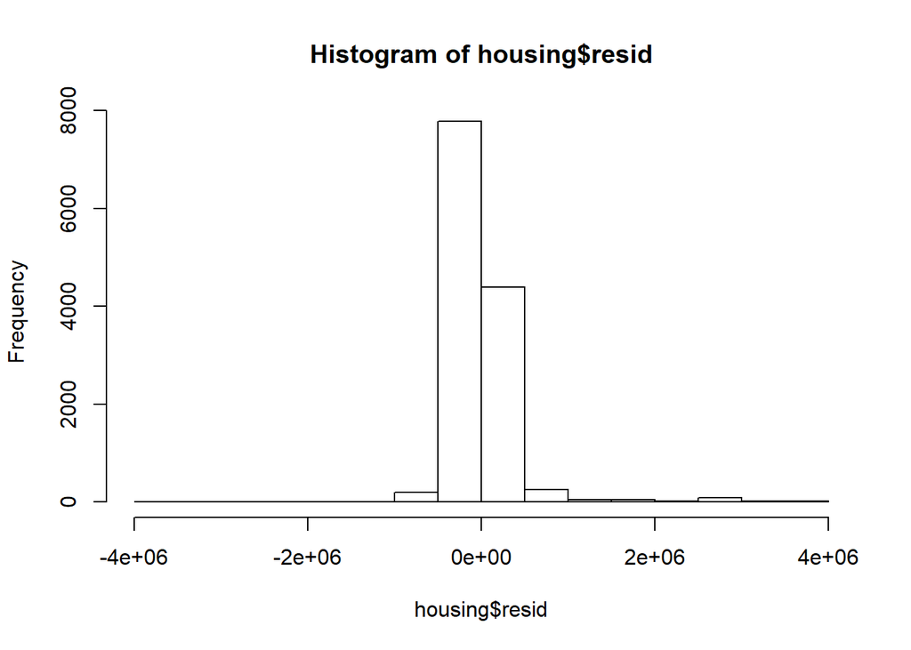

```r
hist(housing$resid)
```

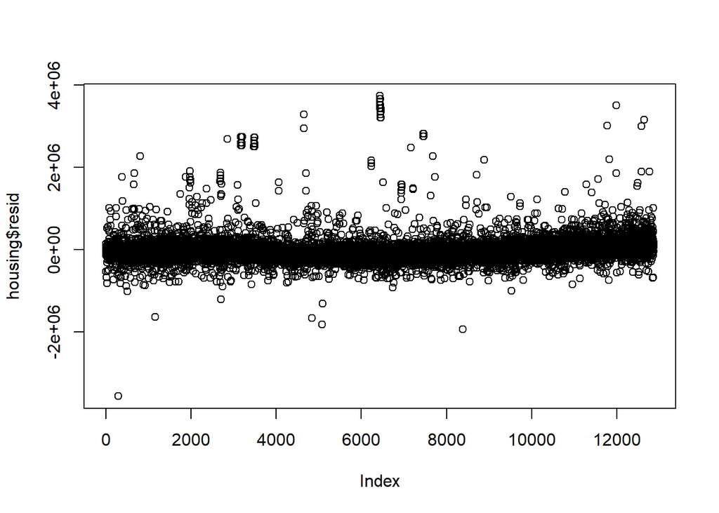

```r
plot(housing$resid)
```

The overwhelming majority of residuals lie close to the mean, with mnost of those being slightly below the mean. There are a few identifiable outliers on the histogram but the scatterplot shows far more.